# Gráfico de áreas

Este es un tipo de gráfico, similar a uno de líneas, en el que el área entre la línea y el eje x se pinta de un color dado, de manera que pueda aportar más información a la presentación de los datos. Para este caso, se va a intentar responder una pregunta sencilla, **¿Se está perdiendo población en la zona pirenaica navarra?**

[figure not shown]

# Librerías

Se cargan las principales librerias que se van a emplear para esta visualización

- **[Pandas](https://python-graph-gallery.com/pandas/)**: para la manipulación de los datos
- **[Matplotlib](https://matplotlib.org/)**: para la visualización de datos
- **[Numpy](https://numpy.org/)**: para operaciones matemáticas

```python
import pandas as pd
import matplotlib.pyplot as plt
import numpy as np
```

# Carga de datos

La fuente de los datos se obtiene del Instituto de Estadistica de Navarra - [Nastat](https://nastat.navarra.es/es/tablas_powerbi/-/tag/censos-poblacion)

Para este caso, se van a buscar los datos de población navarra por años y por municipios. Para esta visualización, no nos interesa los municipios individualmente, sino que nos interesa los municipios que pertenecen a una ZONA concreta de Navarra.

Por ello, lo primero es buscar otro conjunto de datos que nos informe de que municipios pertenecen a las distintas zonas. Esta información se podrá cruzar con el otro conjunto de datos para obtener la población de cada municipio y por último, sumar toda la población para obtener el total de la población en la zona Pirenaica Navarra para cada año.

```python
# Carga de la info de los municipios
df_codigos = pd.read_excel("data/Zonas Navarra 2000.xlsx", skiprows=2)
df_codigos.head()
```

|  | CÓDIGO MUNICIPIO | MUNICIPIOS (272) | CÓDIGO ZONA | ZONA | CÓDIGO SUBZONA | SUBZONA | CÓDIGO ÁREA | ÁREA |
| --- | --- | --- | --- | --- | --- | --- | --- | --- |
| 0 | 1 | Abáigar | 4 | Tierra Estella | 13 | Estella Oriental | 33 | Ega Alto |
| 1 | 2 | Abárzuza / Abartzuza | 4 | Tierra Estella | 13 | Estella Oriental | 34 | Yerri-Guesálaz |
| 2 | 3 | Abaurregaina / Abaurrea Alta | 2 | Pirineo | 9 | Auñamendi | 17 | Aezkoa Sur |
| 3 | 4 | Abaurrepea / Abaurrea Baja | 2 | Pirineo | 9 | Auñamendi | 17 | Aezkoa Sur |
| 4 | 5 | Aberin | 4 | Tierra Estella | 13 | Estella Oriental | 35 | Solana |

```python
# Codigos de municipio de cada uno que pertenece al Pirineo
codigos_pirineo = df_codigos[df_codigos["ZONA"] == "Pirineo"]["CÓDIGO MUNICIPIO"]
```

```python
# Cargar datos de población y eliminar la primera fila
df_poblacion = pd.read_excel("data/Población navarra 2003-2024.xlsx").drop(index=0).reset_index(drop=True)

# Renombrar las dos primeras columnas
df_poblacion = df_poblacion.rename(columns={
    "year": "Código",
    "Unnamed: 1": "Municipio"
})

# Transformar el codigo de texto a numero
df_poblacion = df_poblacion[
    pd.to_numeric(df_poblacion["Código"], errors="coerce").notna()
].reset_index(drop=True)

df_poblacion.head()
```

|  | Código | Municipio | 2003 | 2004 | 2005 | 2006 | 2007 | 2008 | 2009 | 2010 | ... | 2015 | 2016 | 2017 | 2018 | 2019 | 2020 | 2021 | 2022 | 2023 | 2024 |
| --- | --- | --- | --- | --- | --- | --- | --- | --- | --- | --- | --- | --- | --- | --- | --- | --- | --- | --- | --- | --- | --- |
| 0 | 001 | Abáigar | 92 | 97 | 103 | 104 | 101 | 103 | 102 | 102 | ... | 97 | 90 | 88 | 87 | 83 | 82 | 84 | 80 | 82 | 86 |
| 1 | 002 | Abárzuza / Abartzuza | 522 | 514 | 534 | 563 | 579 | 584 | 574 | 577 | ... | 556 | 532 | 524 | 550 | 538 | 544 | 538 | 527 | 514 | 518 |
| 2 | 003 | Abaurregaina / Abaurrea Alta | 156 | 157 | 150 | 147 | 142 | 141 | 140 | 138 | ... | 127 | 127 | 124 | 121 | 126 | 127 | 128 | 120 | 115 | 119 |
| 3 | 004 | Abaurrepea / Abaurrea Baja | 44 | 42 | 41 | 40 | 39 | 41 | 41 | 41 | ... | 35 | 35 | 34 | 33 | 32 | 31 | 29 | 31 | 29 | 29 |
| 4 | 005 | Aberin | 344 | 327 | 328 | 331 | 343 | 351 | 368 | 365 | ... | 376 | 376 | 358 | 356 | 359 | 340 | 346 | 371 | 368 | 383 |

5 rows × 24 columns

## Filtrar los datos de poblacion

```python
# filtrar el otro dataset
df_pob_pirineo = df_poblacion[
    df_poblacion["Código"].astype(int).isin(codigos_pirineo.astype(int))
]

LISTA_POBLACION = df_poblacion.columns.tolist()[2:]

# sumar la columna que te interese
total_pirineo = df_pob_pirineo[LISTA_POBLACION].sum()
```

# Gráfico de área de 2 colores

La ventaja de usar un gráfico de área es que nos permite rellenar con 2 colores y visualizar rápidamente zonas. En este ejemplo, en lugar de mostrar la población, se va a analizar la variación de población de un año a otro.

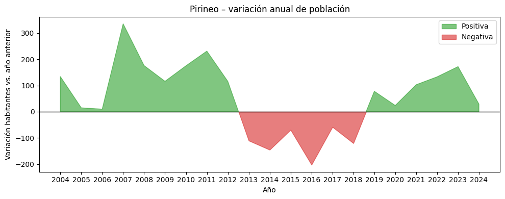

```python
# Ordenar los indices anualmetne
total_pirineo = total_pirineo.sort_index()

# Aseguramos los valores numericos
total_pirineo = total_pirineo.astype(float)

# Calculamos la diferencia de poblacion entre cada año
delta = total_pirineo.diff()
delta = delta.dropna()

x = delta.index.astype(int)
y = delta.values

fig, ax = plt.subplots(figsize=(10, 4))

# área positiva
ax.fill_between(
    x, y, 0,
    where=(y >= 0),
    interpolate=True,
    color="#2ca02c",   # verde
    alpha=0.6,
    label="Positiva"
)

# área negativa
ax.fill_between(
    x, y, 0,
    where=(y < 0),
    interpolate=True,
    color="#d82929",   # rojo
    alpha=0.6,
    label="Negativa"
)

ax.axhline(0, color="black", linewidth=1)
ax.set_title("Pirineo – variación anual de población")
ax.set_xlabel("Año")
ax.set_ylabel("Variación habitantes vs. año anterior")
ax.legend()
ax.set_xticks(x)
plt.tight_layout()
plt.show()
```

### Regresión lineal

Para tener un resultado más claro a la hora de proponer una respuesta, se puede hacer una regresión lineal con los datos para tener una línea de tendencia. Dependiendo de la pendiente de dicha recta, se podrá determinar más fácil y se complementará con el grafico de área si la población aumenta o disminuye.

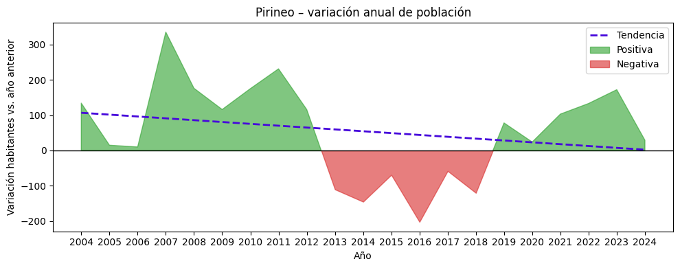

```python
# Calcular la regresión lineal
coef = np.polyfit(x, y, 1)
a, b = coef
tendencia = a * x + b

fig, ax = plt.subplots(figsize=(10, 4))

# Línea de tendencia
ax.plot(
    x,
    tendencia,
    linestyle="--",
    linewidth=2,
    color="#4607db",    # cambia el color si tu fondo es claro
    label="Tendencia"
)

# área positiva
ax.fill_between(
    x, y, 0,
    where=(y >= 0),
    interpolate=True,
    color="#2ca02c",   # verde
    alpha=0.6,
    label="Positiva"
)

# área negativa
ax.fill_between(
    x, y, 0,
    where=(y < 0),
    interpolate=True,
    color="#d82929",   # rojo
    alpha=0.6,
    label="Negativa"
)

ax.axhline(0, color="black", linewidth=1)
ax.set_title("Pirineo – variación anual de población")
ax.set_xlabel("Año")
ax.set_ylabel("Variación habitantes vs. año anterior")
ax.legend()
ax.set_xticks(x)
plt.tight_layout()
plt.show()
```

# Mejora visual

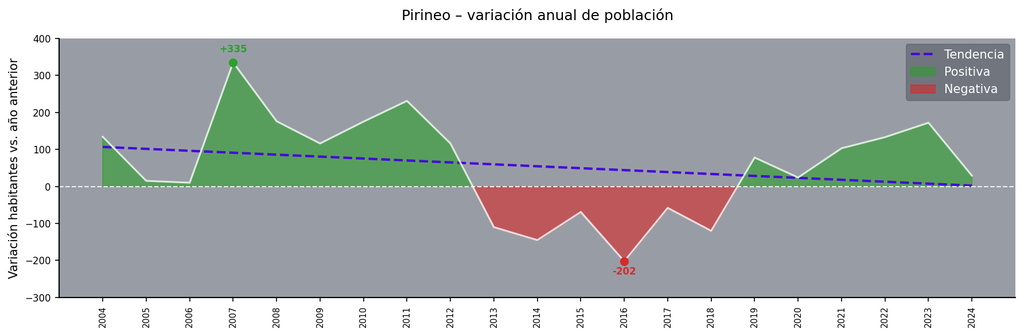

```python
ig, ax = plt.subplots(figsize=(12, 4), dpi=150)
fig.patch.set_facecolor("#989DA5")     # fondo figura
ax.set_facecolor("#989DA5")            # fondo eje

# separar positivos y negativos
pos_mask = y >= 0
neg_mask = y < 0



# Línea de tendencia
ax.plot(
    x,
    tendencia,
    linestyle="--",
    linewidth=2,
    color="#4607db",    # cambia el color si tu fondo es claro
    label="Tendencia"
)

# área positiva
ax.fill_between(
    x, y, 0,
    where=(y >= 0),
    interpolate=True,
    color="#2ca02c",   # verde
    alpha=0.6,
    label="Positiva"
)

# área negativa
ax.fill_between(
    x, y, 0,
    where=(y < 0),
    interpolate=True,
    color="#d82929",   # rojo
    alpha=0.6,
    label="Negativa"
)

# línea más intensa
ax.plot(
    x, y,
    color="#ffffff",
    linewidth=1.5,
    alpha=0.8,
    zorder=3
)


# 4. marcar máximo y mínimo
idx_max = np.argmax(y)
idx_min = np.argmin(y)
x_max, y_max = x[idx_max], y[idx_max]
x_min, y_min = x[idx_min], y[idx_min]

ax.scatter(x_max, y_max, color="#2ca02c", s=40, zorder=5)
ax.scatter(x_min, y_min, color="#d82929", s=40, zorder=5)

# texto del máximo (un poco arriba)
ax.text(
    x_max,
    y_max + (abs(y_max) * 0.05 + 5),
    f"+{y_max:.0f}",
    color="#2ca02c",
    fontsize=8,
    ha="center",
    va="bottom",
    fontweight="bold"
)

# texto del mínimo (un poco abajo)
ax.text(
    x_min,
    y_min - (abs(y_min) * 0.05 + 5),
    f"{y_min:.0f}",
    color="#d82929",
    fontsize=8,
    ha="center",
    va="top",
    fontweight="bold"
)

# línea 0
ax.axhline(0, linestyle="--", color="#eeeeee", linewidth=1)

# jes y ticks
ax.set_xticks(x)
ax.set_xticklabels(x, rotation=90, ha="center", color="#000000", fontsize=7)
ax.set_ylabel("Variación habitantes vs. año anterior", color="#000000")
ax.set_title("Pirineo – variación anual de población", color="#000000", pad=15)
ax.set_ylim([-300, 400])

# spines más visibles
for spine in ["left", "bottom"]:
    ax.spines[spine].set_color("#000000")
    ax.spines[spine].set_linewidth(1)

# quitar los otros
ax.spines["right"].set_visible(False)
ax.spines["top"].set_visible(False)

# ticks de color
ax.tick_params(axis="y", colors="#000000", labelsize=8)

# Legenda
ax.legend(facecolor="#666C75", edgecolor="#666C75", labelcolor="#ffffff")

plt.tight_layout()
plt.show()
```

# Respuesta:

**¿Se está perdiendo población en la zona pirenaica navarra?**